# Sales consulting for Seattle Reign FC

Ankita Pathak

March 22, 2019

**Introduction**

- Sales consulting for Seattle Reign FC, National Women’s Soccer League Team
  - Perform explanatory data analysis
  - Analyze Sales, Attendance, and Merchandise Consumption
  - Determine effectiveness promotions
  - Determine requirements of target audiences
- Survey to find ways to increase ticket sales and attendance, merchandise consumptions
  - Quantity of data measured in terms of year of attendance, number of sales of tickets, total expenditure
  - Data categorized with media, merchandise and timing preferences

**Key Observations**

- With promotions, the highest selling merchandise during the match is Short Sleeve Shirts
- Pepsi is the most popular sponsor for Short Sleeve Shirts
- In the Season 2017, Season Tickets are most likely to sell
- With promotions, most likely College Graduates will attend matches on Saturday Afternoon 1pm

## Examine merchandises that are popular and sell at store, online and during match

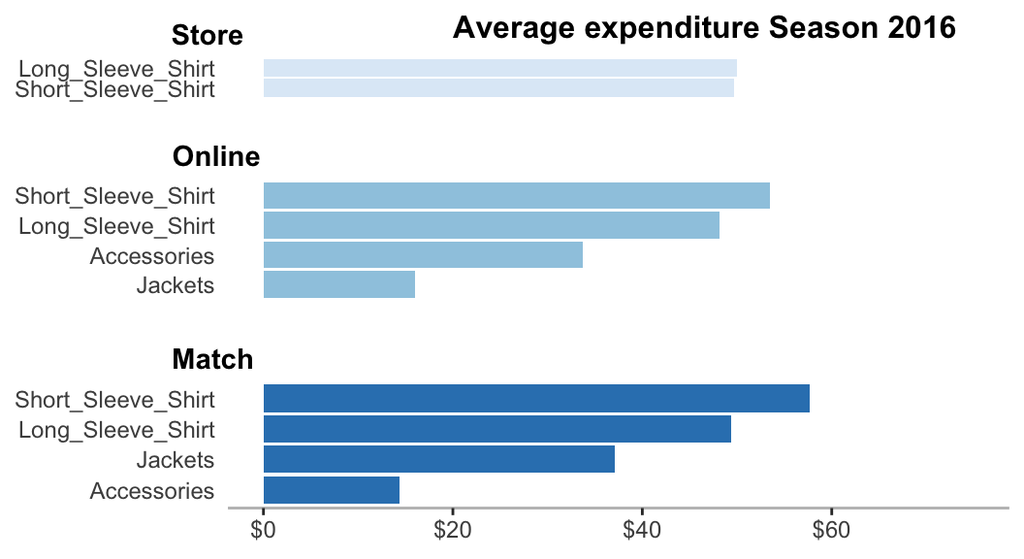

- The expenditure graph above shows that Merchandises are more likely to sell Online or during the Match
  - Short Sleeve Shirts are most popular among all the different types of Merchandises
  - Least popular Merchandise categories are Accessories and Jackets

## Promotional effect on buying preferences and sponsors

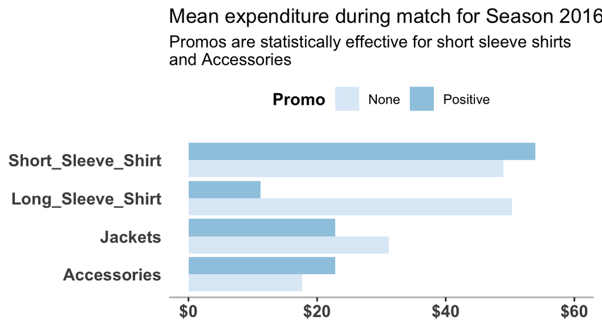

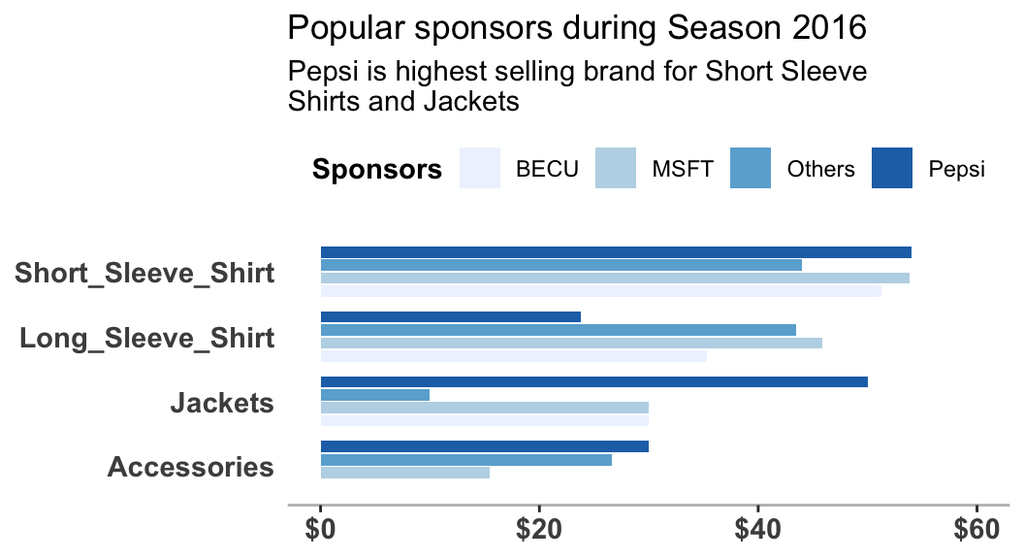

- Key observations
  - Pepsi is among the most popular sponsors of all Merchandises during the Season 2016 except Long Sleeve Shirts
  - Microsoft is the primary sponsor of Long sleeve shirts

## Examine type of tickets that is predicted to sell the most for the upcoming season 2017

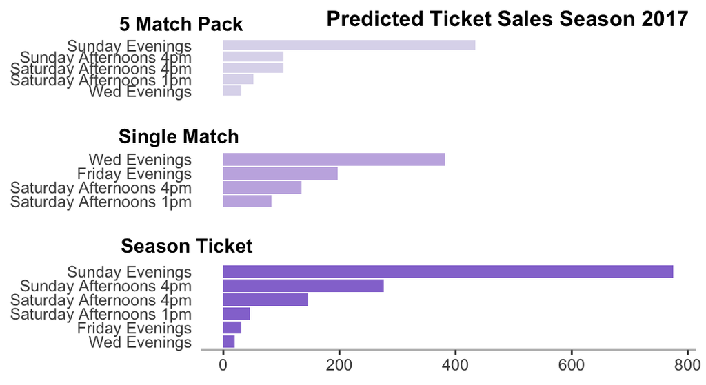

- Key observations
  - Season ticket is predicted to sell highest for the upcoming Season 2017, 5 Match Pack is least likely to sell the least
  - Sunday Evenings is the most popular timing among fans to attend the Seattle Reign FC match

## Examine which type of ticket sells the most and preferred timing of fans

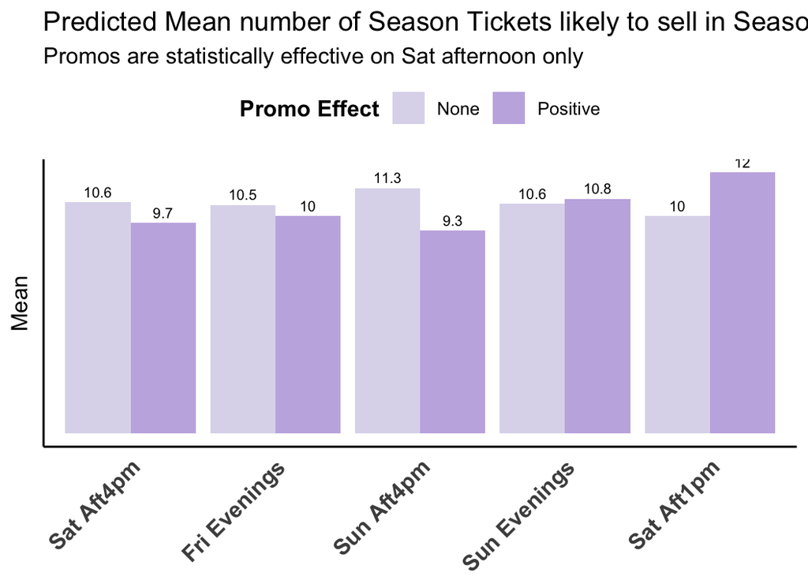

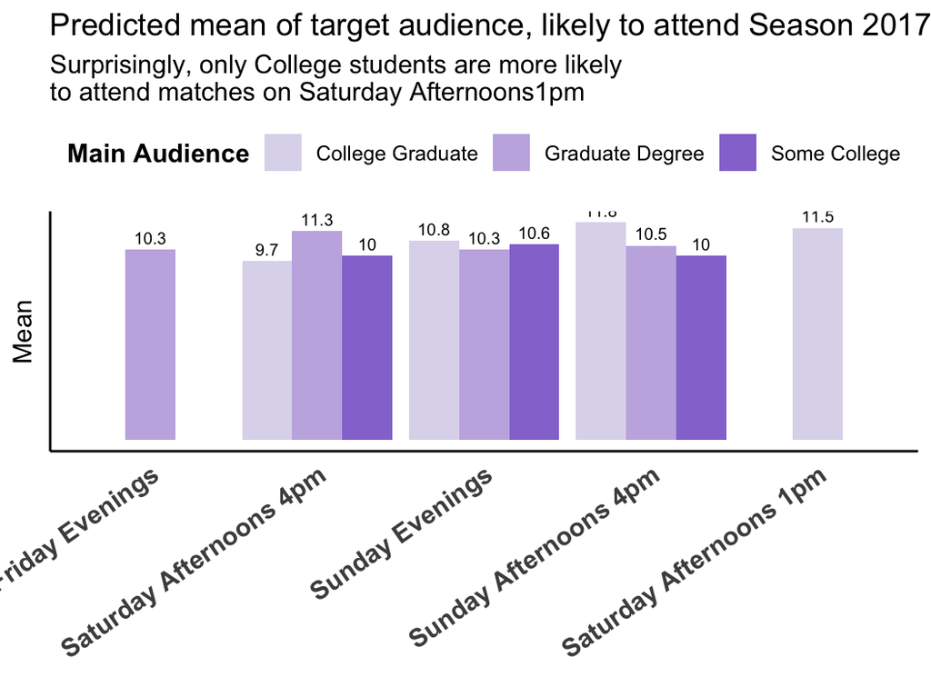

- Key observations
  - Saturday Afternoon 1pm and Sunday Evenings tickets are likely to sell more when promotions are effective
  - Identify target audiences

## Recommendations

1. Long Sleeve Shirts and Jackets are selling with no influence of promotions
   - Promotional strategy:
     - Offers like buy 1 get 1 free, a pack of 2 Short Sleeve Shirts for lesser price
     - Target on what a fan likes the most on Merchandise,like a logo of Seattle Reign FC on front or the logo of Sponsors
2. Saturday Afternoon 1pm and Sunday Evenings, tickets are likely to sell more when promotions are effective
   - Promotional Strategy: - Seasonal Tickets can use certain characters or mascots for as a “free gift with purchase”, Target College students - College and Graduate students are not attending the match on Saturday Afternoons 1pm? Distance? - Additional parking facilities during weekend

**Conclusion**